# CES2017_UFC_UFCG

### Censo da Educação Superior 2017 - UFC/UFCG (Computação)

Cursos de computação das Universidades Federais de Campina Grande, UFCG, e do Ceará campus Fortaleza, UFC.

### Sobre os dados

Os dados utilizados nessa análise são um recorte dos dados originais do [Censo da Educação Superior 2017](http://portal.inep.gov.br/web/guest/censo-da-educacao-superior) que podem ser encontrados no [link: http://portal.inep.gov.br/web/guest/microdados](http://portal.inep.gov.br/web/guest/microdados).

Os recortes dos dados são referentes aos cursos de Bacharelado em Ciência da Computação das Universidades Federais de Campina Grande - UFCG, campus Campina Grande e do Ceará - UFC, campus Fortaleza.

Nos dados estão presentes as seguintes variáves:

**CO_IES** - Código único de identificação da Instituição de Ensino Superior (IES)  
**CO_CURSO** - Código único de identificação do curso gerado pelo E-MEC  
**CO_ALUNO** - Código de identificação gerado pelo Inep para o aluno da educação superior  
**CO_ALUNO_CURSO** - Código de identificação gerado pelo Inep para o vínculo do aluno ao curso  
**TP_COR_RACA** - Código da cor/raça do aluno  
**TP_SEXO** - Informa o sexo do aluno  
**NU_IDADE** - Idade que o aluno completa no ano de referência do Censo  
**TP_NACIONALIDADE** - Código da nacionalidade do aluno  
**TP_DEFICIENCIA** - Informa se o aluno é uma pessoa com deficiência, transtorno global do desenvolvimento ou altas habilidades/superdotação  
**IN_RESERVA_VAGAS** - Informa se o aluno participa de programa de reserva de vagas"  
**IN_APOIO_SOCIAL** - Informa se o aluno recebe algum tipo de apoio social na forma de moradia, transporte, alimentação, material didático e bolsas (trabalho/permanência)  
**IN_ATIVIDADE_EXTRACURRICULAR** - Informa se o aluno participa de algum tipo de atividade extracurricular (estágio não obrigatório, extensão, monitoria e pesquisa)  
**TP_ESCOLA_CONCLUSAO_ENS_MEDIO** - Tipo de escola que o aluno concluiu ensino médio  
**IN_MATRICULA** - Informa se o aluno é matriculado no curso  
**IN_CONCLUINTE** - Informa se o aluno é concluinte  
**IN_INGRESSO_TOTAL** - Informa se o aluno é ingressante no curso, não importando a forma de ingresso utilizada  
**NU_ANO_INGRESSO** - Ano de ingresso do aluno no curso  
**NO_IES** - Nome da IES  
**SG_IES** - Sigla da IES  
**NO_CURSO** - Nome do curso  
**NO_MUNICIPIO** - Nome do Município da IES  
**NO_UF** - Nome da Unidade da Federação da IES

### Importando as bibliotecas necessárias

```python
# Biblioteca científica
import numpy as np
# Biblioteca para análise de dados
import pandas as pd
# Suprimindo os warnings da biblioteca pandas
pd.options.mode.chained_assignment = None
# Bibliotecas de visualização de dados
import matplotlib.pyplot as plt
import matplotlib.patches as mpatches
import matplotlib.ticker as mtick
plt.style.use('ggplot')
import seaborn as sns
sns.set_style('whitegrid')
%matplotlib inline
```

### Carregando e verificando os dados

```python
# Dados do Censo da Educação Superior 2017 (Curso de computação da UFCG e UFC)
df = pd.read_csv('dados/ces2017_ufc_ufcg.csv')
```

```python
# Exibindo o cabeçalho do dataframe
df.head()
```

|  | CO_IES | CO_CURSO | CO_ALUNO | CO_ALUNO_CURSO | TP_COR_RACA | TP_SEXO | NU_IDADE | TP_DEFICIENCIA | IN_RESERVA_VAGAS | IN_APOIO_SOCIAL | ... | TP_ESCOLA_CONCLUSAO_ENS_MEDIO | IN_MATRICULA | IN_CONCLUINTE | IN_INGRESSO_TOTAL | NU_ANO_INGRESSO | NO_IES | SG_IES | NO_CURSO | NO_MUNICIPIO | NO_UF |
| --- | --- | --- | --- | --- | --- | --- | --- | --- | --- | --- | --- | --- | --- | --- | --- | --- | --- | --- | --- | --- | --- |
| 0 | 583 | 13980 | 400002927555 | 10802911 | 2 | 2 | 28 | 1 | 0 | 0 | ... | 2 | 1 | 1 | 0 | 2012 | UNIVERSIDADE FEDERAL DO CEARÁ | UFC | CIÊNCIA DA COMPUTAÇÃO | Fortaleza | CE |
| 1 | 583 | 13980 | 400003487046 | 9700772 | 2 | 2 | 32 | 0 | 0 | 1 | ... | 2 | 1 | 0 | 0 | 2012 | UNIVERSIDADE FEDERAL DO CEARÁ | UFC | CIÊNCIA DA COMPUTAÇÃO | Fortaleza | CE |
| 2 | 583 | 13980 | 400004454309 | 8320376 | 2 | 2 | 40 | 0 | 0 | 0 | ... | 2 | 1 | 0 | 0 | 2012 | UNIVERSIDADE FEDERAL DO CEARÁ | UFC | CIÊNCIA DA COMPUTAÇÃO | Fortaleza | CE |
| 3 | 583 | 13980 | 400004457276 | 8270850 | 2 | 2 | 28 | 0 | 1 | 0 | ... | 1 | 0 | 0 | 0 | 2016 | UNIVERSIDADE FEDERAL DO CEARÁ | UFC | CIÊNCIA DA COMPUTAÇÃO | Fortaleza | CE |
| 4 | 583 | 13980 | 400005696646 | 9703960 | 2 | 2 | 30 | 0 | 0 | 1 | ... | 1 | 1 | 0 | 0 | 2014 | UNIVERSIDADE FEDERAL DO CEARÁ | UFC | CIÊNCIA DA COMPUTAÇÃO | Fortaleza | CE |

5 rows × 21 columns

```python
# Exibindo as informações do dataframe
df.info()
```

```
<class 'pandas.core.frame.DataFrame'>
RangeIndex: 1079 entries, 0 to 1078
Data columns (total 21 columns):
CO_IES                           1079 non-null int64
CO_CURSO                         1079 non-null int64
CO_ALUNO                         1079 non-null int64
CO_ALUNO_CURSO                   1079 non-null int64
TP_COR_RACA                      1079 non-null int64
TP_SEXO                          1079 non-null int64
NU_IDADE                         1079 non-null int64
TP_DEFICIENCIA                   1079 non-null int64
IN_RESERVA_VAGAS                 1079 non-null int64
IN_APOIO_SOCIAL                  1079 non-null int64
IN_ATIVIDADE_EXTRACURRICULAR     1079 non-null int64
TP_ESCOLA_CONCLUSAO_ENS_MEDIO    1079 non-null int64
IN_MATRICULA                     1079 non-null int64
IN_CONCLUINTE                    1079 non-null int64
IN_INGRESSO_TOTAL                1079 non-null int64
NU_ANO_INGRESSO                  1079 non-null int64
NO_IES                           1079 non-null object
SG_IES                           1079 non-null object
NO_CURSO                         1079 non-null object
NO_MUNICIPIO                     1079 non-null object
NO_UF                            1079 non-null object
dtypes: int64(16), object(5)
memory usage: 177.1+ KB
```

```python
# Descrevendo as variáveis numéricas
desc_int = df.drop(['CO_IES', 'CO_CURSO','CO_ALUNO', 'CO_ALUNO_CURSO'], axis=1).describe(include=[np.number])
desc_int.loc['count'] = desc_int.loc['count'].astype(int).astype(str)
desc_int.iloc[1:] = desc_int.iloc[1:].applymap('{:.0f}'.format)
desc_int.T
```

|  | count | mean | std | min | 25% | 50% | 75% | max |
| --- | --- | --- | --- | --- | --- | --- | --- | --- |
| TP_COR_RACA | 1079 | 2 | 1 | 0 | 1 | 2 | 3 | 5 |
| TP_SEXO | 1079 | 2 | 0 | 1 | 2 | 2 | 2 | 2 |
| NU_IDADE | 1079 | 22 | 3 | 16 | 20 | 21 | 23 | 44 |
| TP_DEFICIENCIA | 1079 | 0 | 1 | 0 | 0 | 0 | 0 | 9 |
| IN_RESERVA_VAGAS | 1079 | 0 | 0 | 0 | 0 | 0 | 1 | 1 |
| IN_APOIO_SOCIAL | 1079 | 0 | 0 | 0 | 0 | 0 | 0 | 1 |
| IN_ATIVIDADE_EXTRACURRICULAR | 1079 | 0 | 0 | 0 | 0 | 0 | 0 | 1 |
| TP_ESCOLA_CONCLUSAO_ENS_MEDIO | 1079 | 2 | 0 | 1 | 1 | 2 | 2 | 2 |
| IN_MATRICULA | 1079 | 1 | 0 | 0 | 1 | 1 | 1 | 1 |
| IN_CONCLUINTE | 1079 | 0 | 0 | 0 | 0 | 0 | 0 | 1 |
| IN_INGRESSO_TOTAL | 1079 | 0 | 0 | 0 | 0 | 0 | 0 | 1 |
| NU_ANO_INGRESSO | 1079 | 2015 | 2 | 2010 | 2014 | 2016 | 2016 | 2017 |

```python
# Descrevendo as variáveis categóricas
cat_obj = df.describe(include=[np.object])
cat_obj.T
```

|  | count | unique | top | freq |
| --- | --- | --- | --- | --- |
| NO_IES | 1079 | 2 | UNIVERSIDADE FEDERAL DE CAMPINA GRANDE | 764 |
| SG_IES | 1079 | 2 | UFCG | 764 |
| NO_CURSO | 1079 | 1 | CIÊNCIA DA COMPUTAÇÃO | 1079 |
| NO_MUNICIPIO | 1079 | 2 | Campina Grande | 764 |
| NO_UF | 1079 | 2 | PB | 764 |

## Algumas perguntas

#### Quantos alunos de computação estão matriculados em cada IES?

```python
# Quantos alunos de computação estão matriculados em cada IES?
print("-------------------------------------")
print(df[df['IN_MATRICULA'] == 1].groupby('SG_IES')['CO_ALUNO'].count())
print("-------------------------------------")
```

```
-------------------------------------
SG_IES
UFC     269
UFCG    664
Name: CO_ALUNO, dtype: int64
-------------------------------------
```

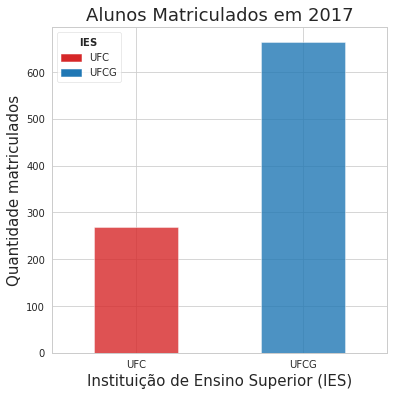

```python
### Gráfico de barras utilizando as bibliotecas pandas e matplotlib

# Definindo a escala de cores manualmente
colors = ['tab:red', 'tab:blue']

# Definindo o tamanho da figura
fig, ax = plt.subplots(figsize=(6,6))

# Gerando a figura
ax = df[df['IN_MATRICULA'] == 1].groupby('SG_IES')['CO_ALUNO'].count().plot.bar(color=colors, alpha=0.8)

# Definindo o título da figura
ax.set_title('Alunos Matriculados em 2017', fontsize=18)

# Definindo o nome do eixo horizontal
ax.set_xlabel('Instituição de Ensino Superior (IES)', fontsize=15)

# Definindo o nome do eixo vertical
ax.set_ylabel('Quantidade matriculados', fontsize=15)

# Definindo a rotação do nome dos atributos
ax.set_xticklabels(ax.get_xticklabels(), rotation=0)

# Definindo a legenda manualmente
l1 = mpatches.Patch(color='tab:red',label='UFC')
l2 = mpatches.Patch(color='tab:blue',label='UFCG')
plt.legend(handles=[l1,l2], title=r'$\bf{IES}$')

# Exibindo a figura sem mensagem de retorno
plt.show()
```

#### Quantos alunos de computação ingressaram no curso em cada IES em 2017?

```python
# Alunos ingressantes no curso de computação de cada IES
print("-------------------------------------")
print(df[df['IN_INGRESSO_TOTAL'] == 1].groupby('SG_IES')['CO_ALUNO'].count())
print("-------------------------------------")
```

```
-------------------------------------
SG_IES
UFC      69
UFCG    201
Name: CO_ALUNO, dtype: int64
-------------------------------------
```

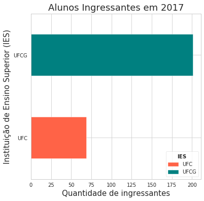

```python
### Gráfico de barras horizontal utilizando as bibliotecas pandas e matplotlib

# Definindo a escala de cores manualmente
colors = ['tomato', 'teal']

# Definindo o tamanho da figura
fig, ax = plt.subplots(figsize=(6,6))

# Gerando a figura
ax = df[df['IN_INGRESSO_TOTAL'] == 1].groupby('SG_IES')['CO_ALUNO'].count().plot.barh(color=colors)

# Definindo o título da figura
ax.set_title('Alunos Ingressantes em 2017', fontsize=18)

# Definindo o nome do eixo horizontal
ax.set_xlabel('Quantidade de ingressantes', fontsize=15)

# Definindo o nome do eixo vertical
ax.set_ylabel('Instituição de Ensino Superior (IES)', fontsize=15)

# Definindo a legenda manualmente
l1 = mpatches.Patch(color='tomato',label='UFC')
l2 = mpatches.Patch(color='teal',label='UFCG')
plt.legend(handles=[l1,l2], title=r'$\bf{IES}$')

# Exibindo a figura sem mensagem de retorno
plt.show()
```

#### Qual o percentual de alunos, por sexo, que estão matriculados em cada IES/curso?

```python
'''
Código - Descrição
1 - Feminino
2 - Masculino
'''
# Criando um novo dataframe com a contagem dos alunos por instituição/sexo
alsx = pd.DataFrame(df.groupby(['SG_IES', 'TP_SEXO'])['CO_ALUNO'].count()).reset_index()

# Subistituíndo os valores 1 e 2 por feminino e masculino
alsx['TP_SEXO'] = np.where(alsx['TP_SEXO'] == 1, 'feminino', 'masculino')

# Renomeando as colunas
alsx.columns = ['IES', 'SEXO', 'QTDE']

# Criando uma coluna com a proporção de alunos por IES/SEXO
alsx['PROP'] = 0.0
for i in range(0, alsx.shape[0]):
    if alsx['IES'][i] == 'UFC':
        alsx['PROP'][i] = round((alsx['QTDE'][i]/(alsx.groupby('IES')['QTDE'].sum().values[0])*100),2)
    else:
        alsx['PROP'][i] = round((alsx['QTDE'][i]/(alsx.groupby('IES')['QTDE'].sum().values[1])*100),2)

# Exibindo o dataframe resultante
alsx
```

|  | IES | SEXO | QTDE | PROP |
| --- | --- | --- | --- | --- |
| 0 | UFC | feminino | 38 | 12.06 |
| 1 | UFC | masculino | 277 | 87.94 |
| 2 | UFCG | feminino | 128 | 16.75 |
| 3 | UFCG | masculino | 636 | 83.25 |

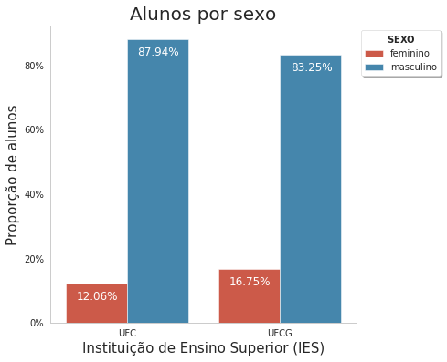

```python
### Gráfico de barras utilizando as bibliotecas pandas, matplotlib e seaborn

# Definindo o tamanho da figura
fig, ax = plt.subplots(figsize=(6,6))

# Gerando a figura
ax = sns.barplot('IES', 'PROP', data=alsx, hue='SEXO')

# Definindo o título da figura
ax.set_title('Alunos por sexo', fontsize=20)

# Definindo o nome do eixo horizontal
ax.set_xlabel('Instituição de Ensino Superior (IES)', fontsize=15)

# Definindo o nome do eixo vertical
ax.set_ylabel('Proporção de alunos', fontsize=15)

# Exibir os valores nas colunas
# -------------------------------#
# Criando uma lista para coletar os dados de plt.patches
totals = []

# Encontrar os valores e acrescentar à lista
for i in ax.patches:
    totals.append(i.get_height())

# Definir rótulos de barra individuais usando a lista acima
total = sum(totals)

# Definir bar lables individuais usando a lista acima
for i in ax.patches:
    # get_x puxa para a esquerda ou para a direita; get_height empurra para cima ou para baixo
    ax.text(i.get_x()+.07, i.get_height()-5, \
            str(round((i.get_height()), 2))+'%', fontsize=12,
                color='white')
# -------------------------------#

# Formatando o eixo vertical como percentagem
ax.yaxis.set_major_formatter(mtick.PercentFormatter())

# Movendo a legenda para a esquerda
ax.legend(loc='upper left', bbox_to_anchor=(1, 1), shadow=True, ncol=1, title=r'$\bf{SEXO}$')

# Remove o grid
ax.grid(False)

# Exibindo a figura sem mensagem de retorno
plt.show()
```

#### Qual o percentual de alunos por cor/raça matriculados em cada curso/IES?

```python
'''
Código - Descrição
0. Aluno não quis declarar cor/raça
1. Branca
2. Preta
3. Parda
4. Amarela
5. Indígena
9. Não dispõe da informação (Não resposta)
'''

# Criando um novo dataframe com a contagem dos alunos por instituição/cor-raça
alrc = pd.DataFrame(df.groupby(['SG_IES', 'TP_COR_RACA'])['CO_ALUNO'].count()).reset_index()

# Subistituíndo os valores por nomes
alrc_replace = { 0 : 'Não declarado', 1 : 'Branca', 2 : 'Preta', 3 : 'Parda', 4 : 'Amarela', 5 : 'Indígena' }
alrc['TP_COR_RACA'] = alrc['TP_COR_RACA'].map(alrc_replace)

# Renomeando as colunas
alrc.columns = ['IES', 'COR_RACA', 'QTDE']

# Criando uma coluna com a proporção de alunos por IES/Cor-Raça
alrc['PROP'] = 0.0
for i in range(0, alrc.shape[0]):
    if alrc['IES'][i] == 'UFC':
        alrc['PROP'][i] = round((alrc['QTDE'][i]/(alrc.groupby('IES')['QTDE'].sum().values[0])*100),2)
    else:
        alrc['PROP'][i] = round((alrc['QTDE'][i]/(alrc.groupby('IES')['QTDE'].sum().values[1])*100),2)

# Exibir o dataframe resultante
alrc
```

|  | IES | COR_RACA | QTDE | PROP |
| --- | --- | --- | --- | --- |
| 0 | UFC | Não declarado | 3 | 0.95 |
| 1 | UFC | Branca | 112 | 35.56 |
| 2 | UFC | Preta | 165 | 52.38 |
| 3 | UFC | Parda | 32 | 10.16 |
| 4 | UFC | Indígena | 3 | 0.95 |
| 5 | UFCG | Não declarado | 1 | 0.13 |
| 6 | UFCG | Branca | 414 | 54.19 |
| 7 | UFCG | Preta | 33 | 4.32 |
| 8 | UFCG | Parda | 287 | 37.57 |
| 9 | UFCG | Amarela | 29 | 3.80 |

```
posx and posy should be finite values
posx and posy should be finite values
posx and posy should be finite values
posx and posy should be finite values
```

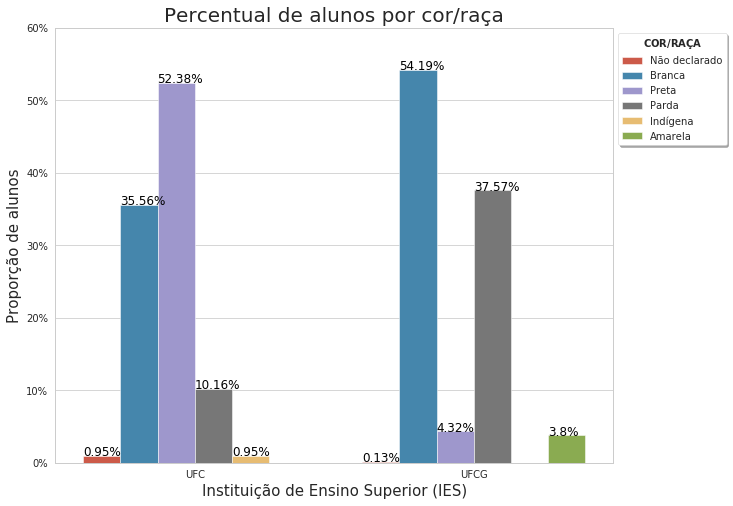

```python
### Gráfico de barras utilizando as bibliotecas pandas, matplotlib e seaborn

# Definindo o tamanho da figura
fig, ax = plt.subplots(figsize=(10,8))

# Gerando a figura
ax = sns.barplot('IES', 'PROP', data=alrc, hue='COR_RACA')

# Definindo o título da figura
ax.set_title('Percentual de alunos por cor/raça', fontsize=20)

# Definindo o nome do eixo horizontal
ax.set_xlabel('Instituição de Ensino Superior (IES)', fontsize=15)

# Definindo o nome do eixo vertical
ax.set_ylabel('Proporção de alunos', fontsize=15)

# Exibir os valores nas colunas
# -------------------------------#
# Criando uma lista para coletar os dados de plt.patches
totals = []

# Encontrar os valores e acrescentar à lista
for i in ax.patches:
    totals.append(i.get_height())

# Definir rótulos de barra individuais usando a lista acima
total = sum(totals)

# Definir bar lables individuais usando a lista acima
for i in ax.patches:
    # get_x puxa para a esquerda ou para a direita; get_height empurra para cima ou para baixo
    ax.text(i.get_x(), i.get_height(), \
            str((i.get_height()))+'%', fontsize=12,
                color='k')
# -------------------------------#

# Formatando o eixo vertical como percentagem
ax.yaxis.set_major_formatter(mtick.PercentFormatter())

# Movendo a legenda para a esquerda
ax.legend(loc='upper left', bbox_to_anchor=(1, 1), shadow=True, ncol=1, title=r'$\bf{COR/RAÇA}$')

# Limites do eixo vertical
ax.set_ylim(0, 60)

# Remove o grid
#ax.grid(False)

# Exibindo a figura sem mensagem de retorno
plt.show()
```

### Quantos alunos concluintes no curso/IES em 2017?

```python
# Quantos alunos concluintes no curso/IES em 2017?
df[df['IN_CONCLUINTE'] == 1].groupby('SG_IES')['CO_ALUNO'].count()
```

```
SG_IES
UFC     36
UFCG    72
Name: CO_ALUNO, dtype: int64
```

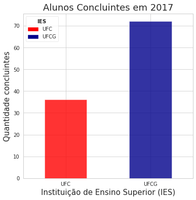

```python
### Gráfico de barras utilizando as bibliotecas pandas e matplotlib

# Definindo a escala de cores manualmente
colors = ['red', 'darkblue']

# Definindo o tamanho da figura
fig, ax = plt.subplots(figsize=(6,6))

# Gerando a figura
ax = df[df['IN_CONCLUINTE'] == 1].groupby('SG_IES')['CO_ALUNO'].count().plot.bar(color=colors, alpha=0.8)

# Definindo o título da figura
ax.set_title('Alunos Concluintes em 2017', fontsize=18)

# Definindo o nome do eixo horizontal
ax.set_xlabel('Instituição de Ensino Superior (IES)', fontsize=15)

# Definindo o nome do eixo vertical
ax.set_ylabel('Quantidade concluintes', fontsize=15)

# Definindo a rotação do nome dos atributos
ax.set_xticklabels(ax.get_xticklabels(), rotation=0)

# Definindo a legenda manualmente
l1 = mpatches.Patch(color='red',label='UFC')
l2 = mpatches.Patch(color='darkblue',label='UFCG')
plt.legend(handles=[l1,l2], title=r'$\bf{IES}$')

# Exibindo a figura sem mensagem de retorno
plt.show()
```

#### Qual é a mínima, a máxima e a mediana das idades dos alunos?

```python
# Qual é a mínima, máxima e a mediana das idades dos alunos?
# Criando um dataframe para receber os atributos
idade = pd.DataFrame()

# Agrupando as idades por IES e calculando a mediana, máximo e mínimo das idades
for row in df.groupby('SG_IES')['NU_IDADE'].agg(['median', 'max', 'min']).itertuples():
    # Criando um dicionário com os atributos calculados
    temp = [{'SG_IES': row.Index, 'idade_minima': row.min, 'idade_maxima': row.max, 'mediana': row.median}]
    # Adicionando os atributos por IES
    idade = idade.append(temp)

# Exibindo o resultado
idade
```

|  | SG_IES | idade_minima | idade_maxima | mediana |
| --- | --- | --- | --- | --- |
| 0 | UFC | 17 | 44 | 22 |
| 0 | UFCG | 16 | 42 | 21 |

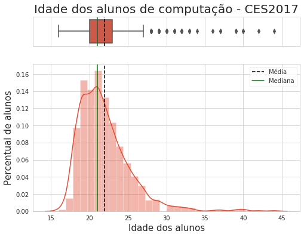

```python
# Definindo a figura
fig, (ax_box, ax_hist) = plt.subplots(2, sharex=True, gridspec_kw= {"height_ratios": (0.2, 1)},
                                     figsize=(8,6))
# Cálculando a média e mediana
media=df['NU_IDADE'].mean()
mediana=df['NU_IDADE'].median()

# Plotando o BoxPlot
sns.boxplot(df['NU_IDADE'], ax=ax_box)
ax_box.axvline(media, color='k', linestyle='--')
ax_box.axvline(mediana, color='g', linestyle='-')

# Plotando o histograma
sns.distplot(df['NU_IDADE'], ax=ax_hist, bins=30, kde=True)
ax_hist.axvline(media, color='k', linestyle='--')
ax_hist.axvline(mediana, color='g', linestyle='-')

# Definindo o título da figura
ax_box.set_title('Idade dos alunos de computação - CES2017', fontsize=20)

# Definindo o nome do eixo horizontal
ax_hist.set_xlabel('Idade dos alunos', fontsize=15)

# Definindo o nome do eixo vertical
ax_hist.set_ylabel('Percentual de alunos', fontsize=15)

# Plotando a legenda
plt.legend({'Média':media,'Mediana':mediana})

# Removendo o label do bloxplot
ax_box.set(xlabel='')

# Exibindo a figura sem mensagem de retorno
plt.show()
```

#### Os alunos concluíram o ensino médio em que tipo de escola?

```python
# Os alunos concluíram o ensino médio em que tipo de escola?
'''
Código - Descrição
1. Pública
2. Privada
'''
# Criando um novo dataframe com a contagem dos alunos por tipo de ensino médio
altem = df.groupby(['SG_IES','TP_ESCOLA_CONCLUSAO_ENS_MEDIO'])['CO_ALUNO'].count().reset_index()

# Subistituíndo os valores 1 e 2 por Pública e Privada
altem['TP_ESCOLA_CONCLUSAO_ENS_MEDIO'] = np.where(altem['TP_ESCOLA_CONCLUSAO_ENS_MEDIO'] == 1, 'Publica',
                                                  'Privada')
# Renomeando as colunas
altem.columns = ['IES', 'ENS_MEDIO', 'QTDE']

# Criando uma coluna com a proporção de alunos por IES/TP_ESCOLA
altem['PROP'] = 0.0
for i in range(0, altem.shape[0]):
    if altem['IES'][i] == 'UFC':
        altem['PROP'][i] = round((altem['QTDE'][i]/(altem.groupby('IES')['QTDE'].sum().values[0])*100),2)
    else:
        altem['PROP'][i] = round((altem['QTDE'][i]/(altem.groupby('IES')['QTDE'].sum().values[1])*100),2)

# Exibindo o dataframe resultante
altem
```

|  | IES | ENS_MEDIO | QTDE | PROP |
| --- | --- | --- | --- | --- |
| 0 | UFC | Publica | 140 | 44.44 |
| 1 | UFC | Privada | 175 | 55.56 |
| 2 | UFCG | Publica | 330 | 43.19 |
| 3 | UFCG | Privada | 434 | 56.81 |

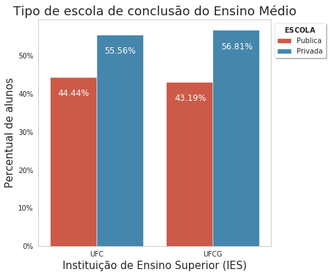

```python
### Gráfico de barras utilizando as bibliotecas pandas, matplotlib e seaborn

# Definindo o tamanho da figura
fig, ax = plt.subplots(figsize=(6,6))

# Gerando a figura
ax = sns.barplot('IES', 'PROP', data=altem, hue='ENS_MEDIO')

# Definindo o título da figura
ax.set_title('Tipo de escola de conclusão do Ensino Médio', fontsize=18)

# Definindo o nome do eixo horizontal
ax.set_xlabel('Instituição de Ensino Superior (IES)', fontsize=15)

# Definindo o nome do eixo vertical
ax.set_ylabel('Percentual de alunos', fontsize=15)

# Exibir os valores nas colunas
# -------------------------------#
# Criando uma lista para coletar os dados de plt.patches
totals = []

# Encontrar os valores e acrescentar à lista
for i in ax.patches:
    totals.append(i.get_height())

# Definir rótulos de barra individuais usando a lista acima
total = sum(totals)

# Definir bar lables individuais usando a lista acima
for i in ax.patches:
    # get_x puxa para a esquerda ou para a direita; get_height empurra para cima ou para baixo
    ax.text(i.get_x()+.07, i.get_height()-5, \
            str(round((i.get_height()), 2))+'%', fontsize=12,
                color='white')
# -------------------------------#

# Formatando o eixo vertical como percentagem
ax.yaxis.set_major_formatter(mtick.PercentFormatter())

# Movendo a legenda para a esquerda
ax.legend(loc='upper left', bbox_to_anchor=(1, 1), shadow=True, ncol=1, title=r'$\bf{ESCOLA}$')

# Remove o grid
ax.grid(False)

# Exibindo a figura sem mensagem de retorno
plt.show()
```

#### Quantos alunos participam de programa de reserva de vagas?

```python
# Quantos dos alunos participam de programa de reserva de vagas?
# Criando um novo dataframe com a contagem dos alunos
alrv = df.groupby(['SG_IES', 'IN_RESERVA_VAGAS'])['CO_ALUNO'].count().reset_index()

# Subistituíndo os valores 1 e 2 por sim e não
alrv['IN_RESERVA_VAGAS'] = np.where(alrv['IN_RESERVA_VAGAS'] == 1, 'Sim',
                                                  'Não')
# Renomeando as colunas
alrv.columns = ['IES', 'RESERVA_VAGAS', 'QTDE']

# Criando uma coluna com a proporção de alunos por IES/RESERVA DE VAGAS
alrv['PROP'] = 0.0
for i in range(0, alrv.shape[0]):
    if alrv['IES'][i] == 'UFC':
        alrv['PROP'][i] = round((alrv['QTDE'][i]/(alrv.groupby('IES')['QTDE'].sum().values[0])*100),2)
    else:
        alrv['PROP'][i] = round((alrv['QTDE'][i]/(alrv.groupby('IES')['QTDE'].sum().values[1])*100),2)

# Exibindo o dataframe resultante
alrv
```

|  | IES | RESERVA_VAGAS | QTDE | PROP |
| --- | --- | --- | --- | --- |
| 0 | UFC | Não | 233 | 73.97 |
| 1 | UFC | Sim | 82 | 26.03 |
| 2 | UFCG | Não | 493 | 64.53 |
| 3 | UFCG | Sim | 271 | 35.47 |

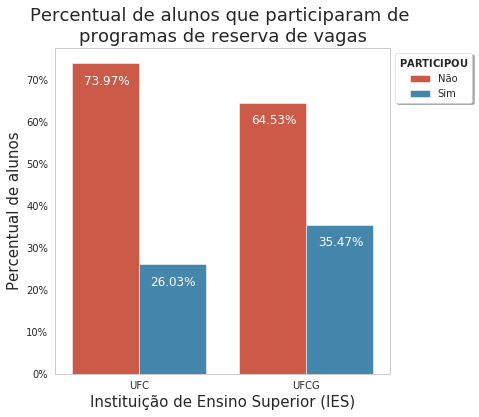

```python
### Gráfico de barras utilizando as bibliotecas pandas, matplotlib e seaborn

# Definindo o tamanho da figura
fig, ax = plt.subplots(figsize=(6,6))

# Gerando a figura
ax = sns.barplot('IES', 'PROP', data=alrv, hue='RESERVA_VAGAS')

# Definindo o título da figura
ax.set_title('Percentual de alunos que participaram de \nprogramas de reserva de vagas', fontsize=18)

# Definindo o nome do eixo horizontal
ax.set_xlabel('Instituição de Ensino Superior (IES)', fontsize=15)

# Definindo o nome do eixo vertical
ax.set_ylabel('Percentual de alunos', fontsize=15)

# Exibir os valores nas colunas
# -------------------------------#
# Criando uma lista para coletar os dados de plt.patches
totals = []

# Encontrar os valores e acrescentar à lista
for i in ax.patches:
    totals.append(i.get_height())

# Definir rótulos de barra individuais usando a lista acima
total = sum(totals)

# Definir bar lables individuais usando a lista acima
for i in ax.patches:
    # get_x puxa para a esquerda ou para a direita; get_height empurra para cima ou para baixo
    ax.text(i.get_x()+.07, i.get_height()-5, \
            str(round((i.get_height()), 2))+'%', fontsize=12,
                color='white')
# -------------------------------#

# Formatando o eixo vertical como percentagem
ax.yaxis.set_major_formatter(mtick.PercentFormatter())

# Movendo a legenda para a esquerda
ax.legend(loc='upper left', bbox_to_anchor=(1, 1), shadow=True, ncol=1, title=r'$\bf{PARTICIPOU}$')

# Remove o grid
ax.grid(False)

# Exibindo a figura sem mensagem de retorno
plt.show()
```

#### Quantos alunos recebem ou receberam algum tipo de apoio social na forma de moradia, transporte, alimentação, material didático e bolsas (trabalho/permanência) ?

```python
# Quantos alunos recebem/receberam algum tipo de apoio social na forma de moradia, transporte, alimentação,
# material didático e bolsas (trabalho/permanência) ?

# Criando um novo dataframe com a contagem dos alunos
alas = df.groupby(['SG_IES', 'IN_APOIO_SOCIAL'])['CO_ALUNO'].count().reset_index()

# Subistituíndo os valores 1 e 2 por sim e não
alas['IN_APOIO_SOCIAL'] = np.where(alas['IN_APOIO_SOCIAL'] == 1, 'Sim',
                                                  'Não')
# Renomeando as colunas
alas.columns = ['IES', 'APOIO_SOCIAL', 'QTDE']

# Criando uma coluna com a proporção de alunos por IES/RES_VAGAS
alas['PROP'] = 0.0
for i in range(0, alas.shape[0]):
    if alas['IES'][i] == 'UFC':
        alas['PROP'][i] = round((alas['QTDE'][i]/(alas.groupby('IES')['QTDE'].sum().values[0])*100),2)
    else:
        alas['PROP'][i] = round((alas['QTDE'][i]/(alas.groupby('IES')['QTDE'].sum().values[1])*100),2)

# Exibindo o dataframe resultante
alas
```

|  | IES | APOIO_SOCIAL | QTDE | PROP |
| --- | --- | --- | --- | --- |
| 0 | UFC | Não | 284 | 90.16 |
| 1 | UFC | Sim | 31 | 9.84 |
| 2 | UFCG | Não | 589 | 77.09 |
| 3 | UFCG | Sim | 175 | 22.91 |

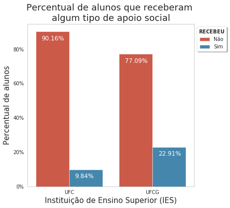

```python
### Gráfico de barras utilizando as bibliotecas pandas, matplotlib e seaborn

# Definindo o tamanho da figura
fig, ax = plt.subplots(figsize=(6,6))

# Gerando a figura
ax = sns.barplot('IES', 'PROP', data=alas, hue='APOIO_SOCIAL')

# Definindo o título da figura
ax.set_title('Percentual de alunos que receberam \nalgum tipo de apoio social', fontsize=18)

# Definindo o nome do eixo horizontal
ax.set_xlabel('Instituição de Ensino Superior (IES)', fontsize=15)

# Definindo o nome do eixo vertical
ax.set_ylabel('Percentual de alunos', fontsize=15)

# Exibir os valores nas colunas
# -------------------------------#
# Criando uma lista para coletar os dados de plt.patches
totals = []

# Encontrar os valores e acrescentar à lista
for i in ax.patches:
    totals.append(i.get_height())

# Definir rótulos de barra individuais usando a lista acima
total = sum(totals)

# Definir bar lables individuais usando a lista acima
for i in ax.patches:
    # get_x puxa para a esquerda ou para a direita; get_height empurra para cima ou para baixo
    ax.text(i.get_x()+.07, i.get_height()-5, \
            str(round((i.get_height()), 2))+'%', fontsize=12,
                color='white')
# -------------------------------#

# Formatando o eixo vertical como percentagem
ax.yaxis.set_major_formatter(mtick.PercentFormatter())

# Movendo a legenda para a esquerda
ax.legend(loc='upper left', bbox_to_anchor=(1, 1), shadow=True, ncol=1, title=r'$\bf{RECEBEU}$')

# Remove o grid
ax.grid(False)

# Exibindo a figura sem mensagem de retorno
plt.show()
```

#### Quantos alunos participam de algum tipo de atividade extracurricular (estágio não obrigatório, extensão, monitoria e pesquisa)?

```python
# Quantos alunos participam de algum tipo de atividade extracurricular (estágio não obrigatório, extensão,
# monitoria e pesquisa)?

# Criando um novo dataframe com a contagem dos alunos
alec = df.groupby(['SG_IES', 'IN_ATIVIDADE_EXTRACURRICULAR'])['CO_ALUNO'].count().reset_index()
# Subistituíndo os valores 1 e 2 por feminino e masculino
alec['IN_ATIVIDADE_EXTRACURRICULAR'] = np.where(alec['IN_ATIVIDADE_EXTRACURRICULAR'] == 1, 'Sim',
                                                  'Não')
# Renomeando as colunas
alec.columns = ['IES', 'AE_CURRICULAR', 'QTDE']

# Criando uma coluna com a proporção de alunos por IES/RES_VAGAS
alec['PROP'] = 0.0
for i in range(0, alec.shape[0]):
    if alec['IES'][i] == 'UFC':
        alec['PROP'][i] = round((alec['QTDE'][i]/(alec.groupby('IES')['QTDE'].sum().values[0])*100),2)
    else:
        alec['PROP'][i] = round((alec['QTDE'][i]/(alec.groupby('IES')['QTDE'].sum().values[1])*100),2)
# Exibir o dataframe resultante
alec
```

|  | IES | AE_CURRICULAR | QTDE | PROP |
| --- | --- | --- | --- | --- |
| 0 | UFC | Não | 298 | 94.60 |
| 1 | UFC | Sim | 17 | 5.40 |
| 2 | UFCG | Não | 687 | 89.92 |
| 3 | UFCG | Sim | 77 | 10.08 |

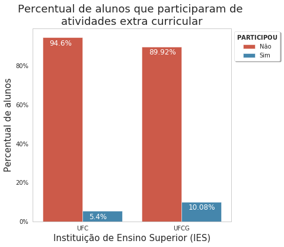

```python
### Gráfico de barras utilizando as bibliotecas pandas, matplotlib e seaborn

# Definindo o tamanho da figura
fig, ax = plt.subplots(figsize=(6,6))

# Gerando a figura
ax = sns.barplot('IES', 'PROP', data=alec, hue='AE_CURRICULAR')

# Definindo o título da figura
ax.set_title('Percentual de alunos que participaram de \natividades extra curricular', fontsize=18)

# Definindo o nome do eixo horizontal
ax.set_xlabel('Instituição de Ensino Superior (IES)', fontsize=15)

# Definindo o nome do eixo vertical
ax.set_ylabel('Percentual de alunos', fontsize=15)

# Exibir os valores nas colunas
# -------------------------------#
# Criando uma lista para coletar os dados de plt.patches
totals = []

# Encontrar os valores e acrescentar à lista
for i in ax.patches:
    totals.append(i.get_height())

# Definir rótulos de barra individuais usando a lista acima
total = sum(totals)

# Definir bar lables individuais usando a lista acima
for i in ax.patches:
    # get_x puxa para a esquerda ou para a direita; get_height empurra para cima ou para baixo
    ax.text(i.get_x()+.07, i.get_height()-4, \
            str(round((i.get_height()), 2))+'%', fontsize=12,
                color='white')
# -------------------------------#

# Formatando o eixo vertical como percentagem
ax.yaxis.set_major_formatter(mtick.PercentFormatter())

# Movendo a legenda para a esquerda
ax.legend(loc='upper left', bbox_to_anchor=(1, 1), shadow=True, ncol=1, title=r'$\bf{PARTICIPOU}$')

# Remove o grid
ax.grid(False)

# Exibindo a figura sem mensagem de retorno
plt.show()
```

#### Quantos alunos apresentam alguma deficiência, transtorno global do desenvolvimento ou altas habilidades/superdotação?

```python
# Quantos alunos apresentam alguma deficiência, transtorno global do desenvolvimento ou altas
# habilidades/superdotação?

# Criando um novo dataframe com a contagem dos alunos
altd = df.groupby(['SG_IES', 'TP_DEFICIENCIA'])['CO_ALUNO'].count().reset_index()

# Subistituíndo os códigos pela descrição
altd_replace = { 0 : 'Não', 1 : 'Sim', 9 : 'Não declarou'}
altd['TP_DEFICIENCIA'] = altd['TP_DEFICIENCIA'].map(altd_replace)

# Renomeando as colunas
altd.columns = ['IES', 'DEFICIENCIA', 'QTDE']

# Criando uma coluna com a proporção de alunos por IES/RES_VAGAS
altd['PROP'] = 0.0
for i in range(0, altd.shape[0]):
    if altd['IES'][i] == 'UFC':
        altd['PROP'][i] = round((altd['QTDE'][i]/(altd.groupby('IES')['QTDE'].sum().values[0])*100),2)
    else:
        altd['PROP'][i] = round((altd['QTDE'][i]/(altd.groupby('IES')['QTDE'].sum().values[1])*100),2)

# Exibindo o dataframe resultante
altd
```

|  | IES | DEFICIENCIA | QTDE | PROP |
| --- | --- | --- | --- | --- |
| 0 | UFC | Não | 300 | 95.24 |
| 1 | UFC | Sim | 7 | 2.22 |
| 2 | UFC | Não declarou | 8 | 2.54 |
| 3 | UFCG | Não | 758 | 99.21 |
| 4 | UFCG | Sim | 6 | 0.79 |

```
posx and posy should be finite values
posx and posy should be finite values
```

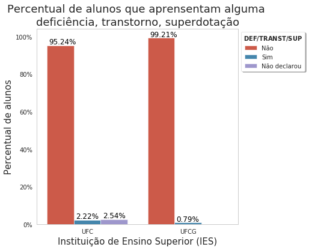

```python
### Gráfico de barras utilizando as bibliotecas pandas, matplotlib e seaborn

# Definindo o tamanho da figura
fig, ax = plt.subplots(figsize=(6,6))

# Gerando a figura
ax = sns.barplot('IES', 'PROP', data=altd, hue='DEFICIENCIA')

# Definindo o título da figura
ax.set_title('Percentual de alunos que aprensentam alguma \ndeficiência, transtorno, superdotação', fontsize=18)

# Definindo o nome do eixo horizontal
ax.set_xlabel('Instituição de Ensino Superior (IES)', fontsize=15)

# Definindo o nome do eixo vertical
ax.set_ylabel('Percentual de alunos', fontsize=15)

# Exibir os valores nas colunas
# -------------------------------#
# Criando uma lista para coletar os dados de plt.patches
totals = []

# Encontrar os valores e acrescentar à lista
for i in ax.patches:
    totals.append(i.get_height())

# Definir rótulos de barra individuais usando a lista acima
total = sum(totals)

# Definir bar lables individuais usando a lista acima
for i in ax.patches:
    # get_x puxa para a esquerda ou para a direita; get_height empurra para cima ou para baixo
    ax.text(i.get_x()+0.02, i.get_height()+0.8, \
            str(round((i.get_height()), 2))+'%', fontsize=12,
                color='k')
# -------------------------------#

# Formatando o eixo vertical como percentagem
ax.yaxis.set_major_formatter(mtick.PercentFormatter())

# Movendo a legenda para a esquerda
ax.legend(loc='upper left', bbox_to_anchor=(1, 1), shadow=True, ncol=1, title=r'$\bf{DEF/TRANST/SUP}$')

# Remove o grid
ax.grid(False)

# Exibindo a figura sem mensagem de retorno
plt.show()
```